# QuEST coding workshop day 2: tidyverse introduction

### Facetting

Separating data into a group of several plots is done with *facets*:

```r
gg_hist <- ggplot(diamonds, aes(x = carat, fill = cut)) +
  geom_histogram() +
  facet_grid(cut ~ ., scales = 'free')
```

An example of a barplot (histogram for discrete variable) with 2d facetting:

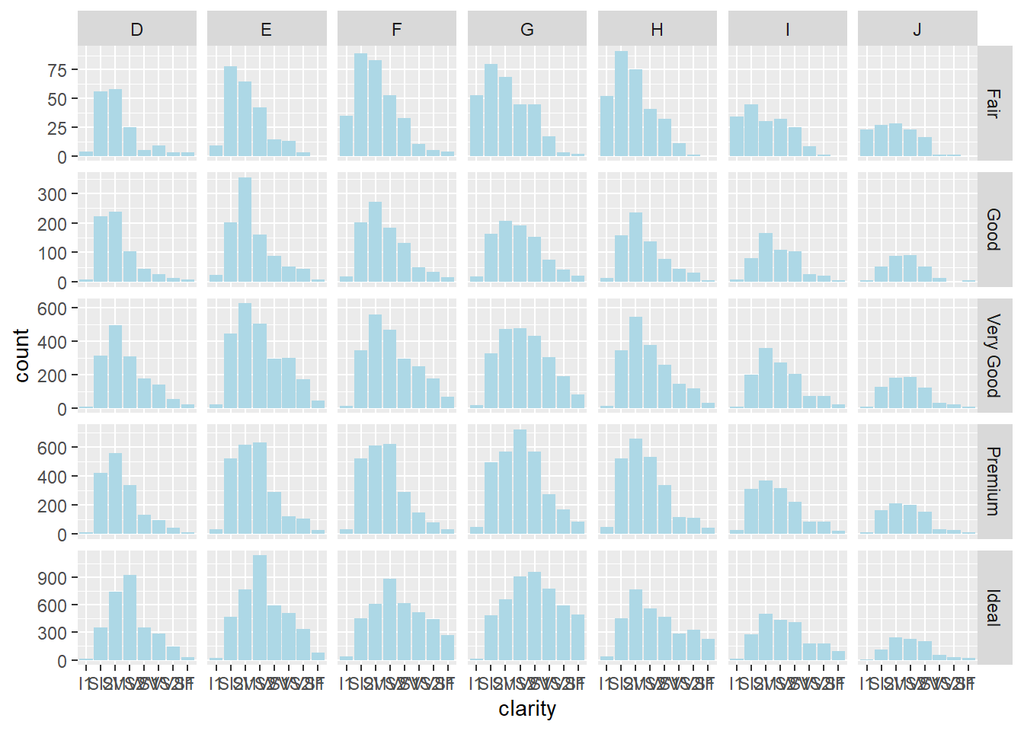

```r
ggplot(diamonds, aes(x = clarity)) +
  geom_bar(fill = 'lightblue') +
  facet_grid(cut ~ color, scales = 'free')
```

### Changing color schemes and other scales

There are tons of different approaches to customizing color with ggplot, and its easy to get overwhelmed! Here we’ll focus on the essentials and leave you to research different color palettes or making your own.

Basically, color is changed through scaling a color aesthetic (`col` or `fill`). Going back to our histogram example, here we use one of the color palettes provided by `RColorBrewer` for discrete variables:

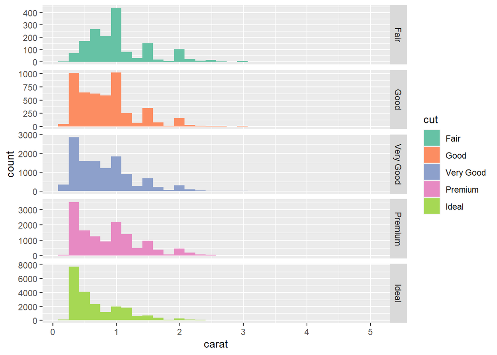

```r
library(RColorBrewer)

my_brew_pal <- brewer.pal(8, 'Set2')

gg_hist +
  scale_fill_discrete(type = my_brew_pal)
```

As we see above, a color palette can be stored and used in multiple plots. For presentations or papers, it can be nice to have a set of specific colors fixed for a variable of interest. An easy way to do this in ggplot is with `scale_*_manual`. Say we want all plots using a mapping with `cut` to have consistent colors:

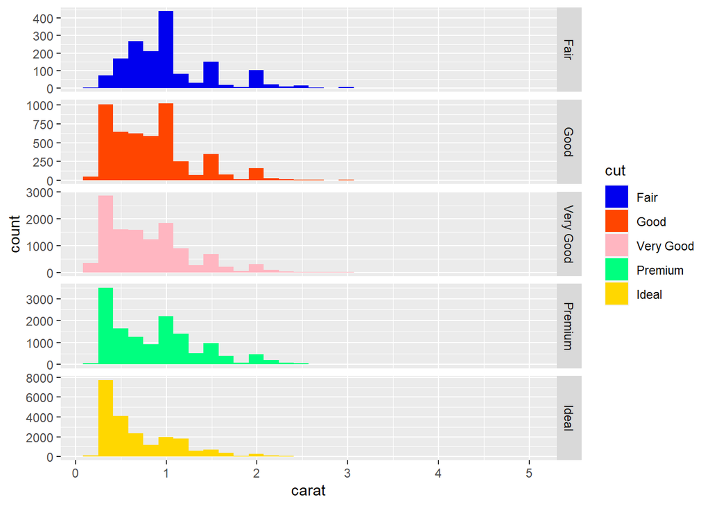

```r
my_pal <- c('blue2', 'orangered', 'lightpink', 'springgreen', 'gold')
names(my_pal) <- levels(diamonds$cut)

gg_hist +
  scale_fill_manual(values = my_pal)
```

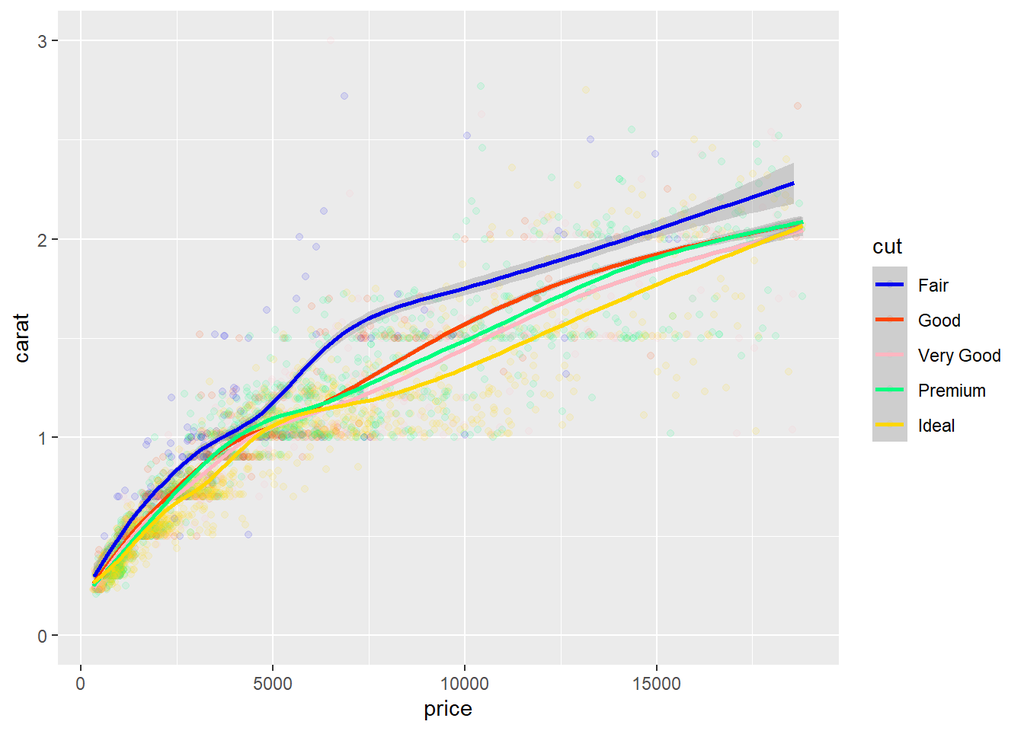

```r
ggplot(diamonds, aes(price, carat, col = cut)) +
  geom_point(alpha = 0.1, data = slice_sample(diamonds, prop = 0.1)) +
  geom_smooth() +
  scale_color_manual(values = my_pal) +
  ylim(0, 3)
```

In general, use `scale_*_discrete` or `scale_*_continuous` if you want to provide existing palettes or do other scaling functions (we’ll see another use of scale in a moment), and `scale_*_manual` for making a discrete palette by hand.

Aesthetics other than color can be scaled in much the same way. A common example is shape:

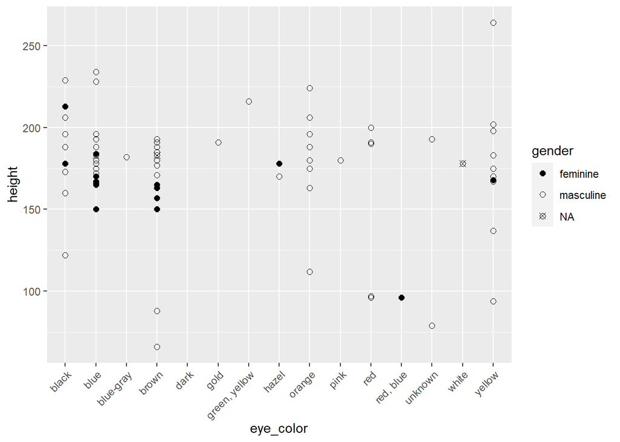

```r
ggplot(starwars, aes(eye_color, height, shape = gender)) + # col is continuous here
  geom_point(size = 2) +
  scale_shape_manual(values = c(19, 1), na.value = 13) +
  scale_x_discrete(guide = guide_axis(angle = 45))
```

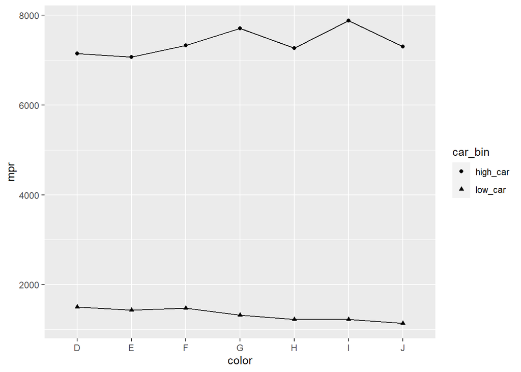

```r
diamonds |>
  mutate(car_bin = ifelse(carat < mean(carat), 'low_car', 'high_car')) |>
  group_by(car_bin, color) |>
  summarize(mpr = mean(price)) |>
  ggplot(aes(color, mpr, shape = car_bin, group = car_bin)) +
  geom_point() +
  geom_line()
```

### Going further

- The [R Graphics Cookbook](https://r-graphics.org/) has tons of examples for all things ggplot.
- Chapter 3 in R4DS is a good review of ggplot concepts and basics, with exercises.

## Bonus: for-loop frenzy

### Control flow review

The functions documented in `?Control` are *reserved* words. That means you can’t name a variable or function one of these words. Going over some basic examples:

```r
## foo: add or subtract a and c, depending on b
foo <- function(a, b = 3, c) {
  if (a < b)
    ret <- bar(a, c)
  else
    ret <- bat(a, c)
  return(ret)
}

bar <- function(d, e) d + e

bat <- function(f, g) f - g

foo(1, c = 4)
```

```
## [1] 5
```

```r
for (i in 1:10)
  print(paste0(i, ':', foo(i, c = 4)))
```

```
## [1] "1:5"
## [1] "2:6"
## [1] "3:-1"
## [1] "4:0"
## [1] "5:1"
## [1] "6:2"
## [1] "7:3"
## [1] "8:4"
## [1] "9:5"
## [1] "10:6"
```

Use `break` to skip out of a for/while loop entirely, or `next` to skip to the next iteration:

```r
fav_fruits <- c('blueberry', 'orange')
enemy_fruit <- 'honeydew'
for (l in fruit) {
  if (l %in% fav_fruits) {
    print('yum')
    next
  }
  if (l == enemy_fruit) {
    print('ewwwww!')
    break
  }
  print(paste0("I don't like ", l))
}
```

```
## [1] "I don't like apple"
## [1] "I don't like apricot"
## [1] "I don't like avocado"
## [1] "I don't like banana"
## [1] "I don't like bell pepper"
## [1] "I don't like bilberry"
## [1] "I don't like blackberry"
## [1] "I don't like blackcurrant"
## [1] "I don't like blood orange"
## [1] "yum"
## [1] "I don't like boysenberry"
## [1] "I don't like breadfruit"
## [1] "I don't like canary melon"
## [1] "I don't like cantaloupe"
## [1] "I don't like cherimoya"
```

[output cut: 22 more lines]

### For-loop challenge

#### Exercise 1

Write a function `boxR` that takes arguments `w` and `h` and prints a $w \times h$ rectangle of `*`s. Hints: use nested for loops, and use `cat('*')` to print `*` without moving to a newline, and `cat('\n')` to move to a newline.

*Solution*

```r
boxR <- function(w, h) {
  for (i in 1:w) {
    for (j in 1:h) {
      cat('*')
    }
    cat('\n')
  }
}

boxR(3, 4)
```

#### Exercise 2

A programming rite of passage. Write a function `triangleR` that takes odd integer `b` and prints an isosceles triangle with base $b$. Hint: draw pictures!

*Solution*

```r
triangleR <- function(b) {
  space <- (b - 1) %/% 2
  for (i in space:0) {
    for (j in 1:b) {
      if (j <= i | j > b - i)
        cat(' ')
      else
        cat('*')
    }
    cat('\n')
  }
}

triangleR(11)
```

## Bonus: network analysis with tidygraph + ggraph

`tidygraph` is a package for constructing and analyzing graphs with a workflow similar to tidyr/dplyr, and `ggraph` is a package similar to ggplot for visualization.

```r
library(tidygraph)
library(ggraph)
```

In tidygraph, a graph is represented with two tibbles: one of nodes (vertices) and one of edges (links). These tibbles are bundled together as one object called a `tbl_graph`.

```r
(graph <- create_ring(10))
```

```
## # A tbl_graph: 10 nodes and 10 edges
## #
## # An undirected simple graph with 1 component
## #
## # Node Data: 10 x 0 (active)
## # ... with 4 more rows
## #
## # Edge Data: 10 x 2
##    from    to
##   <int> <int>
## 1     1     2
## 2     2     3
## 3     3     4
## # ... with 7 more rows
```

In ggraph, a graph is plotted in “layers” just like ggplot. There are specific geoms for nodes and edges:

```r
gg_net <- ggraph(graph) +
  geom_node_point(color = 'blue', size = 5)
```

```
## Using `stress` as default layout
```

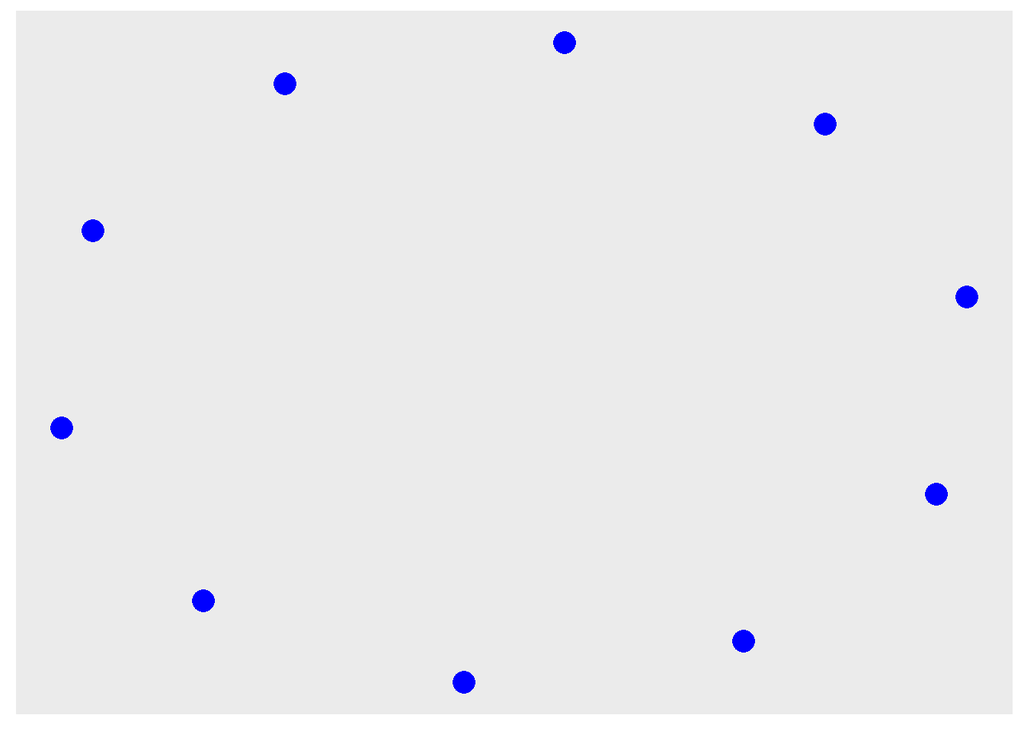

```r
gg_net
```

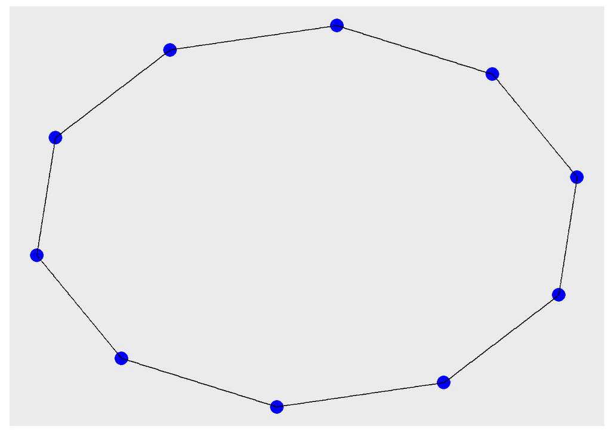

```r
gg_net +
  geom_edge_link()
```

### dplyr verbs on graphs

Since a `tbl_graph` is made of tibbles, we can use all the familiar functions on them:

```r
graph <- graph |>
  mutate(name = fruit[1:n()])
```

```r
graph <- graph |>
  activate(edges) |>
  mutate(weight = runif(n(), 1, 5))
```

Also, `%N>%` can be used as shorthand for `|> activate(nodes) |>`, and `%E>%` for activating edges.

Attributes can be used in aesthetic mappings when plotting. As with all geoms, check which aesthetics can be controlled with a mapping with `?geom_node_*` etc.

```
## Using `stress` as default layout
```

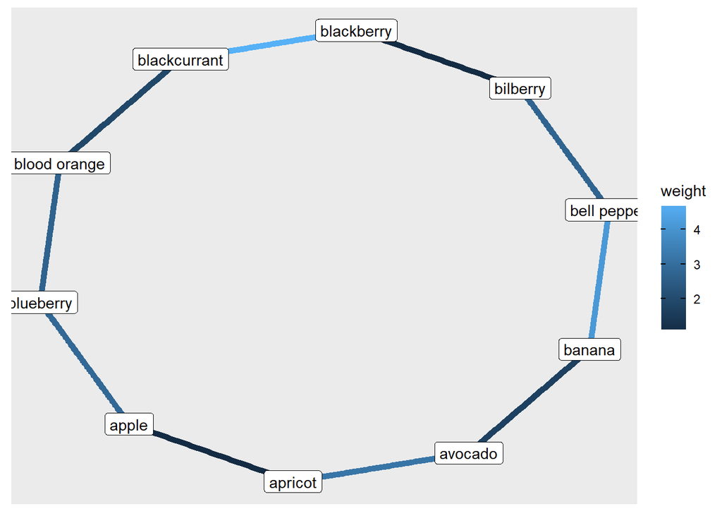

```r
ggraph(graph) +
  geom_edge_link(mapping = aes(edge_color = weight), edge_width = 2) +
  geom_node_label(mapping = aes(label = name))
```